# Practical Machine Learning Project

PDBolier

26..27 oktober 2016

## Preamble

Based on the data from the website http://groupware.les.inf.puc-rio.br/har we want to predict which excerices were performed. The data is generated by using accelerometers on the belt, forearm, arm, and dumbell of 6 participants. They were asked to perform barbell lifts correctly and incorrectly in 5 different ways. More information is available from the website here: http://groupware.les.inf.puc-rio.br/har (see the section on the Weight Lifting Exercise Dataset).

By analysing the given data a model is build with the goal to predict the manner in which the excercises were performed.

Part of our approach is to use cross validation, so we follow the steps:

- use the training set
- split the training set into a training and test set
- build a model on the training set
- evaluate on the test set (which was split od the training set)
- repeat …

However, first we need to:

- have a specific question: which exercise was the participant performing
- have a look at the input data
- extract features
- derive at an algorithm
- find best parameters
- evaluate and reach a conclusion.

### Notice

The data for this project come from this source: http://groupware.les.inf.puc-rio.br/har, they have been very generous in allowing their data to be used for this kind of assignment.

## Loading the data

The raw data is generated as described on the site http://groupware.les.inf.puc-rio.br/har.

To decrease the downloads, the training set (https://d396qusza40orc.cloudfront.net/predmachlearn/pml-training.csv) and test set (https://d396qusza40orc.cloudfront.net/predmachlearn/pml-testing.csv) were first downloaded manually. Then the data is read into a dataframe.

Note that we found, using summary, that some fields contain a text “#DIV/0!”. This values is intepreted as ‘NA’. Several iteration were used to get a cleaner data set.

```r
# Note na.strings
pml.training.set <- read.csv("pml-training.csv", header = TRUE, na.strings = c("NA", "#DIV/0!", "", " "))
pml.testing.set  <- read.csv("pml-testing.csv" , header = TRUE, na.strings = c("NA", "#DIV/0!", "", " "))
```

## Exploration of the data

First we have a quick peek at the training data

```r
# size
nrow(pml.training.set)
```

```
## [1] 19622
```

```r
ncol(pml.training.set)
```

```
## [1] 160
```

```r
# summary(pml.training.set) # too much to show.
# head(plm.training.set) # too much to show
```

Looking at a summary (not shown here) we (assume) that we can remove the following fields:

- ‘X’ is a row counter so it does not add any important information for this analysis
- user_name, is the user name, also assumed to be not important for this analysis.
- new_window, indicating a new measurment window is started

Additionally (as a first attempt) we also drop the columns with a lot of NA values (more than 80%)

If the test (later on) shows that our model is bad we may reconsider.

When building the model we must take the following aspect into account:

- raw_timestamp_part_1, is (part of) a timestamp, so we will not use it for building the model (yet)
- raw_timestamp_part_2, ..
- cvtd_timestamp, ..
- num_window, part of time related administration (or so it seems)
- classe, which is the outcome, or dependent variable.

Since there are timestamps used there may be a time relation in the data and thus the processing should be in chunks of the data. For a first approach we will ignore the timestamps.

```r
library(caret)
#library(doMC) # multi core, only on Linux
library(doParallel)
# drop fields X, user_name and those with more than 80% NA's
dropNAcols <- colnames(pml.training.set)[colSums(is.na(pml.training.set))/nrow(pml.training.set) > 0.8] # > 80% NA's
dropcols   <- c(dropNAcols,  c("X", "user_name", "new_window"))

trainingsubcol <- pml.training.set[, !(names(pml.training.set) %in% dropcols), drop=FALSE]
ncol(trainingsubcol)
```

```
## [1] 57
```

```r
#summary(training) # shows too much data

# Quick check for type of data
#sapply(training, class) # check type of data

# Dont forget to prepare both training and test set
testingsubcol <- pml.testing.set[, !(names(pml.testing.set) %in% dropcols), drop=FALSE]
ncol(testingsubcol)
```

```
## [1] 57
```

## split up the training set

```r
set.seed(20161027)
inTraining <- createDataPartition(y = trainingsubcol$classe, p = 0.60, list = FALSE)
training.train <- trainingsubcol[ inTraining, ] # select rows as generated
training.test  <- trainingsubcol[-inTraining, ] # select rows the opposite set

# we keep the testingsubcol set for later
```

## Quick look

Just to get a somewhat better idea, we make a featerplot

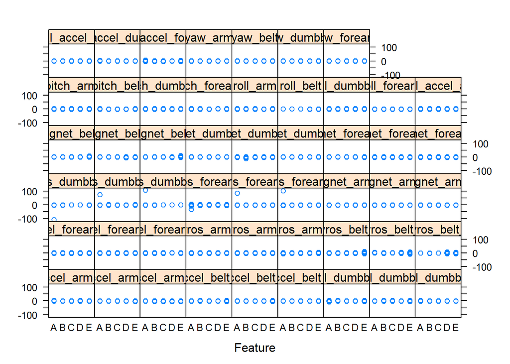

```r
# columns 1..4 and the last one are not use, 57 is the outcome.
preprocessObj   <- preProcess(training.train[,c(-(1:4), -57)], method=c("center", "scale"))
trainingPrepped <- predict(preprocessObj, training.train[,c(-(1:4), -57)]) # drop uninteresting columns
trainingPrepped$classe <- training.train$classe

# TODO enlarge plot somehow.
featurePlot(x=trainingPrepped[,-53], y=trainingPrepped$classe) # now 53 is the outcome
```

```r
# dont forget to prep the test set
testingPrepped <- predict(preprocessObj, training.test[,c(-(1:4), -57)]) # drop uninteresting columns
testingPrepped$classe <- training.test$classe

# prep the 20 cases
test20cases <- predict(preprocessObj, testingsubcol[,c(-(1:4))]) # drop uninteresting columns
```

Well (as one might expect) the plot does not reveal a lot but does show there are differences for the feature (classe). For a better look we may plot less feature (after determining the most important).

## Building the model(s)

Since we only have a set of outcomes (A..E), we’re trying to build a classification model. A basic classificaton model can be build using rpart. From the model we check which predictors are used of the 52 we have.

```r
set.seed(20161027)

rpart.control  = trainControl(method = "repeatedCV", number = 10, repeats = 10, classProbs = TRUE, verboseIter = FALSE, savePredictions = TRUE)
modelfit.rpart = train (classe ~ . , trainingPrepped, method = "rpart", tuneLength=20, trControl=rpart.control)
# Lets see the predictors
length(predictors(modelfit.rpart)) # how many
```

```
## [1] 48
```

```r
predictors(modelfit.rpart) # which ones.
```

```
##  [1] "roll_belt"            "pitch_forearm"        "magnet_dumbbell_y"
##  [4] "roll_forearm"         "magnet_dumbbell_z"    "gyros_arm_y"
##  [7] "yaw_belt"             "accel_dumbbell_y"     "pitch_belt"
## [10] "magnet_belt_z"        "yaw_forearm"          "magnet_forearm_z"
## [13] "yaw_dumbbell"         "roll_dumbbell"        "yaw_arm"
## [16] "magnet_arm_y"         "accel_forearm_x"      "total_accel_dumbbell"
## [19] "magnet_belt_y"        "accel_belt_z"         "total_accel_belt"
## [22] "accel_belt_x"         "accel_dumbbell_x"     "accel_dumbbell_z"
## [25] "gyros_dumbbell_y"     "accel_forearm_z"      "magnet_belt_x"
## [28] "accel_belt_y"         "magnet_forearm_y"     "gyros_arm_x"
## [31] "magnet_forearm_x"     "pitch_arm"            "gyros_forearm_x"
## [34] "pitch_dumbbell"       "accel_arm_z"          "accel_forearm_y"
## [37] "gyros_belt_z"         "total_accel_forearm"  "magnet_dumbbell_x"
## [40] "magnet_arm_z"         "roll_arm"             "gyros_dumbbell_x"
## [43] "gyros_belt_x"         "total_accel_arm"      "magnet_arm_x"
## [46] "accel_arm_x"          "accel_arm_y"          "gyros_belt_y"
```

```r
# so how does the model look like?
library(rattle)
```

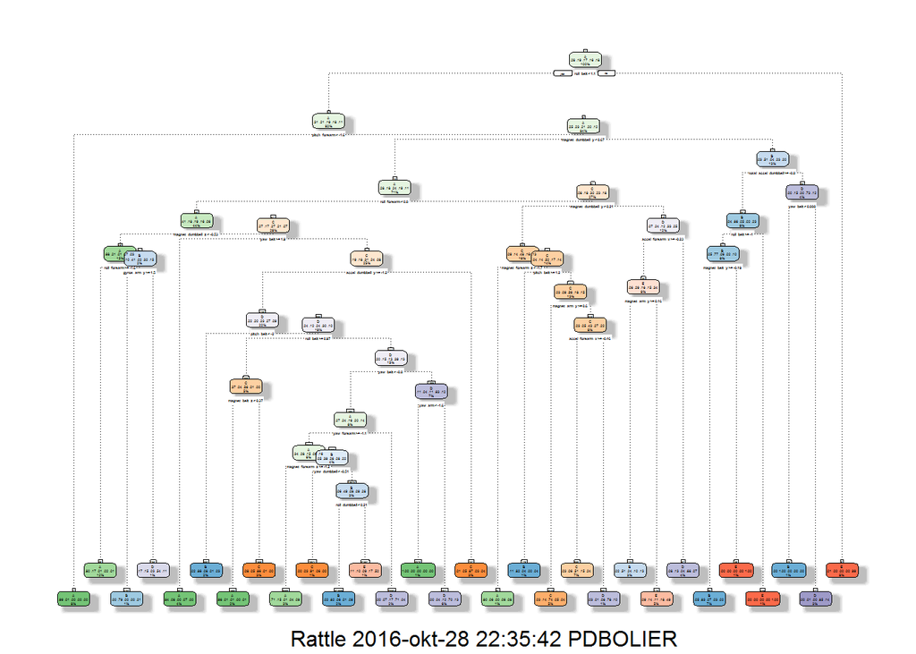

```r
fancyRpartPlot(model = modelfit.rpart$finalModel)
```

```r
# we might check for the importance
modelfit.rpart$finalModel$variable.importance
```

```
##            roll_belt           pitch_belt         accel_belt_z
##          1516.624170           953.896494           950.575650
##        pitch_forearm      accel_forearm_x         roll_forearm
##           755.511116           623.879522           617.752622
##             yaw_belt     total_accel_belt     accel_dumbbell_y
##           604.221990           600.207755           571.455460
## total_accel_dumbbell        magnet_belt_z    magnet_dumbbell_y
##           540.292384           539.171430           508.377717
##         accel_belt_y        magnet_belt_x        roll_dumbbell
##           385.702992           378.852792           354.347643
##    magnet_dumbbell_z        magnet_belt_y     magnet_forearm_z
##           329.532343           312.160068           306.519018
##     magnet_forearm_y     accel_dumbbell_x          yaw_forearm
##           287.551985           247.866065           245.460195
##              yaw_arm         accel_belt_x      accel_forearm_z
##           243.345406           241.480042           232.805512
##      accel_forearm_y     magnet_forearm_x         magnet_arm_y
##           196.890878           173.658261           166.598867
##     accel_dumbbell_z         gyros_belt_z         magnet_arm_x
##           165.025582           144.273477           127.174446
##            pitch_arm          accel_arm_x         yaw_dumbbell
##           125.340099           115.989229           107.591309
##          gyros_arm_x          gyros_arm_y         magnet_arm_z
##            97.974015            94.305599            94.281923
##     gyros_dumbbell_y          accel_arm_y  total_accel_forearm
##            88.465519            73.472171            55.876423
##         gyros_belt_y      total_accel_arm       pitch_dumbbell
##            54.057656            33.281528            28.690028
##          accel_arm_z             roll_arm         gyros_belt_x
##            26.538151            19.036871            17.301784
##    magnet_dumbbell_x     gyros_dumbbell_x      gyros_forearm_x
##            14.516323             6.385143             2.976366
```

```r
# printcp(modelfit.rpart$finalModel) too much, (http://stackoverflow.com/questions/9666212/how-to-compute-error-rate-from-a-decision-tree)
# modelfit.rpart$finalModel[[1]] # shows the accuray / tuned parameters

# Wanted to use lasso to determine predictors, took too long ... mmm.
```

The ‘rpart’ model so far uses a 48 preditors, almost all. The tree is too complex to get a proper idea.

Lets see how the model performs, using the test set, since we have a classification challenge we can use a confusion matrix to check the performance.

```r
predictions.rpart <- predict(modelfit.rpart$finalModel, testingPrepped, type = "class")
confusionMatrix(predictions.rpart, testingPrepped$classe)
```

```
## Confusion Matrix and Statistics
##
##           Reference
## Prediction    A    B    C    D    E
##          A 2041  221   20   43   40
##          B   53  991  120   48   74
##          C   47  135 1082  100  159
##          D   54  104   98 1024  157
##          E   37   67   48   71 1012
##
## Overall Statistics
##
##                Accuracy : 0.7838
##                  95% CI : (0.7746, 0.7929)
##     No Information Rate : 0.2845
##     P-Value [Acc > NIR] : < 2.2e-16
##
##                   Kappa : 0.7263
##  Mcnemar's Test P-Value : < 2.2e-16
##
## Statistics by Class:
##
##                      Class: A Class: B Class: C Class: D Class: E
## Sensitivity            0.9144   0.6528   0.7909   0.7963   0.7018
## Specificity            0.9423   0.9534   0.9319   0.9370   0.9652
## Pos Pred Value         0.8630   0.7706   0.7104   0.7126   0.8194
## Neg Pred Value         0.9652   0.9197   0.9548   0.9591   0.9350
## Prevalence             0.2845   0.1935   0.1744   0.1639   0.1838
## Detection Rate         0.2601   0.1263   0.1379   0.1305   0.1290
## Detection Prevalence   0.3014   0.1639   0.1941   0.1832   0.1574
## Balanced Accuracy      0.9284   0.8031   0.8614   0.8667   0.8335
```

So the rpart model reaches an accuracy of 0.7838, i.e. 78.38%. Which seems ok, but can we do better.

For a second model we use a random forest model, and for the fird we use a neural net; lets see what results it will bring us.

Note: I wanted to use a boosted model (gbm) but after an hour I had to stop.

```r
library(randomForest)
# this one takes too much time: modelfit.gbm <- train(classe ~ . , data = trainingPrepped, method="gbm", verbose=FALSE)

modelfit.rf <- randomForest(classe ~ ., data = trainingPrepped, method="rf")
predictions.rf <- predict(modelfit.rf, testingPrepped, type = "class")
confusionMatrix(predictions.rf, testingPrepped$classe)
```

```
## Confusion Matrix and Statistics
##
##           Reference
## Prediction    A    B    C    D    E
##          A 2232    7    0    0    0
##          B    0 1504    8    0    0
##          C    0    7 1358   10    0
##          D    0    0    2 1276    7
##          E    0    0    0    0 1435
##
## Overall Statistics
##
##                Accuracy : 0.9948
##                  95% CI : (0.9929, 0.9962)
##     No Information Rate : 0.2845
##     P-Value [Acc > NIR] : < 2.2e-16
##
##                   Kappa : 0.9934
##  Mcnemar's Test P-Value : NA
##
## Statistics by Class:
##
##                      Class: A Class: B Class: C Class: D Class: E
## Sensitivity            1.0000   0.9908   0.9927   0.9922   0.9951
## Specificity            0.9988   0.9987   0.9974   0.9986   1.0000
## Pos Pred Value         0.9969   0.9947   0.9876   0.9930   1.0000
## Neg Pred Value         1.0000   0.9978   0.9985   0.9985   0.9989
## Prevalence             0.2845   0.1935   0.1744   0.1639   0.1838
## Detection Rate         0.2845   0.1917   0.1731   0.1626   0.1829
## Detection Prevalence   0.2854   0.1927   0.1752   0.1638   0.1829
## Balanced Accuracy      0.9994   0.9948   0.9950   0.9954   0.9976
```

```r
# Last and 3rd model
modelfit.nnet <- train(classe  ~ .,  data = trainingPrepped, method = "nnet", trControl = trainControl(method = "CV", number = 10), linear.output=FALSE, trace=FALSE)
predictions.nnet <- predict(modelfit.nnet, testingPrepped, type = "raw")
confusionMatrix(predictions.nnet, testingPrepped$classe)
```

```
## Confusion Matrix and Statistics
##
##           Reference
## Prediction    A    B    C    D    E
##          A 1906  229  168  112   23
##          B  130  954  108   34  278
##          C   63  224 1032  115  142
##          D  120   35   34  971  101
##          E   13   76   26   54  898
##
## Overall Statistics
##
##                Accuracy : 0.7343
##                  95% CI : (0.7243, 0.744)
##     No Information Rate : 0.2845
##     P-Value [Acc > NIR] : < 2.2e-16
##
##                   Kappa : 0.6628
##  Mcnemar's Test P-Value : < 2.2e-16
##
## Statistics by Class:
##
##                      Class: A Class: B Class: C Class: D Class: E
## Sensitivity            0.8539   0.6285   0.7544   0.7551   0.6227
## Specificity            0.9052   0.9131   0.9160   0.9558   0.9736
## Pos Pred Value         0.7818   0.6343   0.6548   0.7700   0.8416
## Neg Pred Value         0.9397   0.9111   0.9464   0.9522   0.9198
## Prevalence             0.2845   0.1935   0.1744   0.1639   0.1838
## Detection Rate         0.2429   0.1216   0.1315   0.1238   0.1145
## Detection Prevalence   0.3107   0.1917   0.2009   0.1607   0.1360
## Balanced Accuracy      0.8796   0.7708   0.8352   0.8554   0.7982
```

And the neural net shows an accuracy of 0.7343, i.e. 73.43%, not good.

The random forest model looks the best (and seems to excute the fastest (TODO measure timing))

## Testing 20 use cases

The testset with the 20 testcases will be used to see if our model is capable of predicting most cases…

```r
# predict the 20 testcases
predict(modelfit.rf, test20cases)
```

```
##  1  2  3  4  5  6  7  8  9 10 11 12 13 14 15 16 17 18 19 20
##  B  A  B  A  A  E  D  B  A  A  B  C  B  A  E  E  A  B  B  B
## Levels: A B C D E
```

## Conclusions

The random forest model is the best model for this particular data set.

Unfortunately most steps took quite a lot of computation time, even though I attempted to use multicore processing. Even with 8 cores the modelling took a lot of time while the core were not at all fully used for computation.